# Test2

Venkat Kolli

May 9, 2018

# Load Libraries

```r
##load any librarys you may need.  tidyverse has already been loaded here for you
libraries <- c("tidyverse", "datasets", "PKNCA","plotly", "knitr")
for (l in libraries) {
  suppressPackageStartupMessages(library(l, character.only = TRUE))
}
```

## Data

```r
data(Theoph)
```

```r
##please add any corresponding data cleanup as needed
dm <- read.csv("dm.csv")
dm<-rename(dm, Subject=SUBJECT, Sex=SEX)
dm$Sex<-recode(dm$Sex, Male='M', Female='F')
dm$Age<-gsub("[^0-9.]", "",dm$Age)
dm$Age<-as.numeric(dm$Age)
dm<-mutate(dm, Age_new=if_else(Age > 1000, Age/52, if_else(Age>100, Age/12, Age) ))
```

## Data Cleaning:

The dm data comprised of three columns and 12 rows. Here the column titles were renamed to keep them consistent throughout this assessment. The Sex column values comprised of gender with two different styles of notations. The values in this column were recoded to maintain an uniform notation. The Age column values also consisted of multiple styles of representations. Here also, the values in age column were altered to maintain consistency.Prior to cleanup, One assumption was made for subject 6 that age was in months instead of years.

## Characteriization of data by gender

Prior to characterization, both datasets were joined into one after converting the subjects in dm dataset as factors. The resulting dataframe, data,column title for concentration was tweaked to match the rest of the titles.

```r
##input characterization and summary data code here.
dm$Subject<-factor(dm$Subject)
data<-left_join(Theoph, dm, by="Subject")
data$Sex<-factor(data$Sex)
data<-rename(data, Conc=conc)
library(psych)
describeBy(data, data$Sex)
```

```
##
##  Descriptive statistics by group
## group: F
##          vars  n   mean     sd median trimmed   mad  min     max   range
## Subject*    1 66   7.33   2.51   7.50    7.41  2.22  3.0   11.00    8.00
## Wt          2 66  72.83   7.97  70.50   72.24  8.45 64.6   86.40   21.80
## Dose        3 66   4.34   0.64   4.53    4.41  0.60  3.1    4.95    1.85
## Time        4 66   5.88   6.94   3.55    4.51  4.88  0.0   24.43   24.43
## Conc        5 66   4.37   2.48   4.65    4.44  2.71  0.0    9.03    9.03
## Sex*        6 66   1.00   0.00   1.00    1.00  0.00  1.0    1.00    0.00
## Age         7 66 504.93 793.92  54.65  368.06 18.53 41.7 2200.00 2158.30
## Age_new     8 66  48.15   8.94  42.95   46.88  1.40 41.7   66.00   24.30
##           skew kurtosis    se
## Subject* -0.31    -0.73  0.31
## Wt        0.59    -1.14  0.98
## Dose     -0.94    -0.42  0.08
## Time      1.53     1.57  0.85
## Conc     -0.27    -1.03  0.31
## Sex*       NaN      NaN  0.00
## Age       1.50     0.54 97.72
## Age_new   1.18    -0.22  1.10
## --------------------------------------------------------
## group: M
##          vars  n   mean     sd median trimmed   mad   min    max  range
## Subject*    1 66   5.67   4.06   4.50    5.48  4.45  1.00  12.00  11.00
## Wt          2 66  66.33   9.12  66.45   66.16 10.75 54.60  79.60  25.00
## Dose        3 66   4.91   0.68   4.85    4.91  0.82  4.02   5.86   1.84
## Time        4 66   5.91   6.97   3.51    4.53  4.78  0.00  24.65  24.65
## Conc        5 66   5.55   3.12   6.01    5.64  3.46  0.00  11.40  11.40
## Sex*        6 66   2.00   0.00   2.00    2.00  0.00  2.00   2.00   0.00
## Age         7 66 211.88 248.46  52.65  179.99 17.87 32.80 678.00 645.20
## Age_new     8 66  46.15   9.49  49.55   46.48  8.90 32.80  56.50  23.70
##           skew kurtosis    se
## Subject*  0.45    -1.39  0.50
## Wt        0.10    -1.59  1.12
## Dose      0.07    -1.64  0.08
## Time      1.54     1.59  0.86
## Conc     -0.29    -1.06  0.38
## Sex*       NaN      NaN  0.00
## Age       0.98    -0.74 30.58
## Age_new  -0.47    -1.54  1.17
```

## Summary of data:

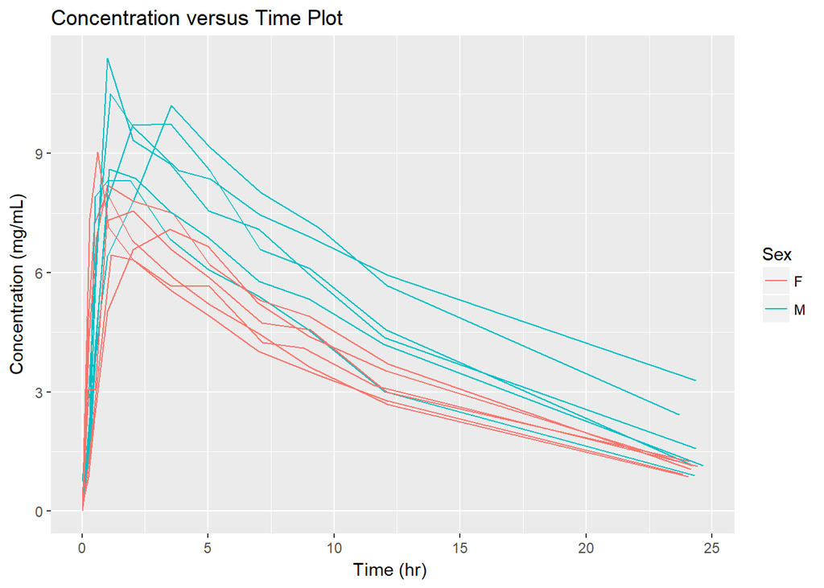

```r
library(ggplot2)
#Plot for concentration versus time stratified by gender
plot1<- ggplot(data, aes(Time, Conc))+geom_line(aes(line = Subject, color=Sex))+labs(x="Time (hr) ", y="Concentration (mg/mL)", title= "Concentration versus Time Plot")
plot1
```

```r
#ggplotly(plot1, session="knitr")
```

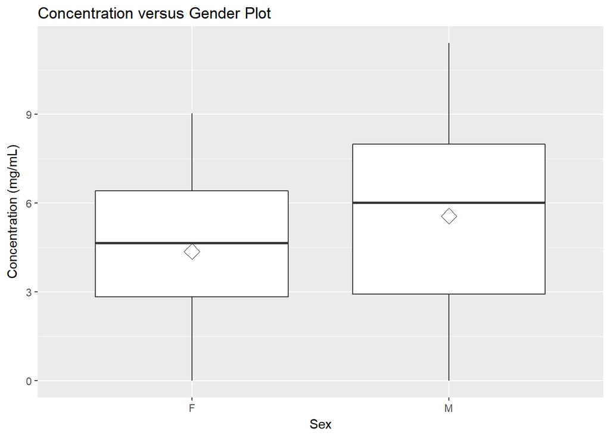

```r
plot2<-ggplot(data, aes(x=Sex, y=Conc)) + geom_boxplot() +
    stat_summary(fun.y=mean, geom="point", shape=5, size=4)+ labs(x="Sex", y="Concentration (mg/mL)", title= "Concentration versus Gender Plot")
plot2
```

```r
#p2<-ggplotly(plot2)
#htmlwidgets::saveWidget(as_widget(p2), "plot2.html")
```

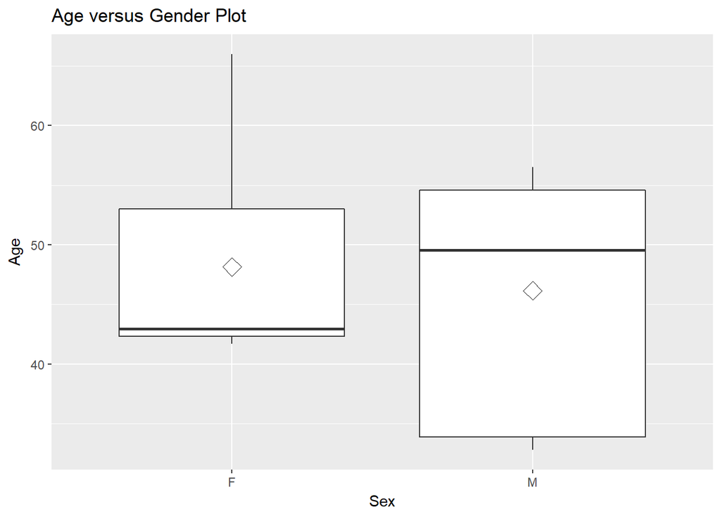

```r
plot3<-ggplot(data, aes(x=Sex, y=Age_new)) + geom_boxplot() +
    stat_summary(fun.y=mean, geom="point", shape=5, size=4) + labs(x="Sex", y="Age", title= "Age versus Gender Plot")
plot3
```

```r
#p3<-ggplotly(plot3)
#htmlwidgets::saveWidget(as_widget(p3), "plot3.html")
```

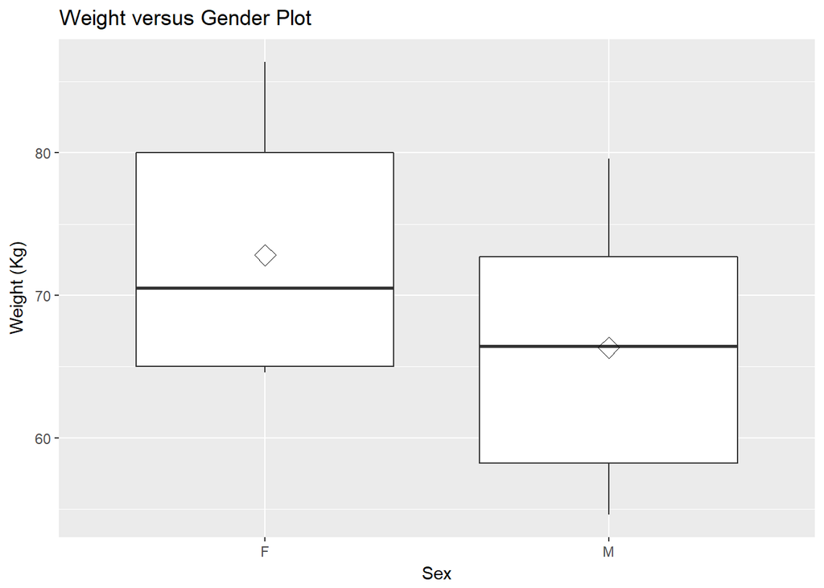

```r
plot4<-ggplot(data, aes(x=Sex, y=Wt)) + geom_boxplot() +
    stat_summary(fun.y=mean, geom="point", shape=5, size=4)+ labs(x="Sex", y="Weight (Kg)", title= "Weight versus Gender Plot")
plot4
```

```r
#p4<-ggplotly(plot4)
#htmlwidgets::saveWidget(as_widget(p4), "plot4.html")
```

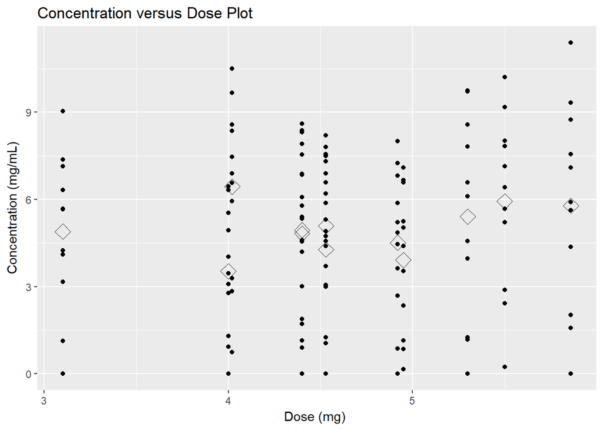

```r
plot5<-ggplot(data, aes(x=Dose, y=Conc, group= Subject)) + geom_point() +
    stat_summary(fun.y=mean, geom="point", shape=5, size=4)+ labs(x="Dose (mg) ", y="Concentration (mg/mL)", title= "Concentration versus Dose Plot")
plot5
```

```r
#p5<-ggplotly(plot5)
#htmlwidgets::saveWidget(as_widget(p5), "plot5.html")
```

The plot represents the concentration versus dose plot with the diamond representing the mean concentration values.Here we observed that for higher doses the maximum concentrations were comparitively higher. On the contrary, for dose around 4 mg, the maximum concentrations were significantly higher than the doses (>4.1 & <5.5) maximum concentrations. These could be due to the weight and gender of the subjects.

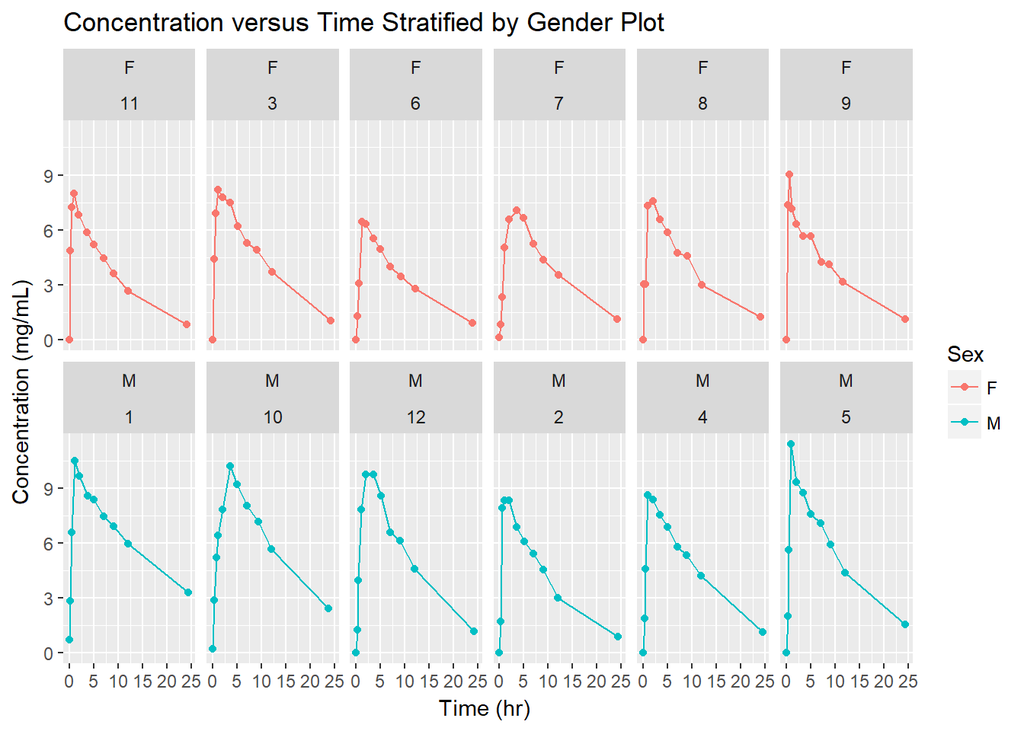

```r
##input visualization code here
p<-ggplot(data=data, aes(x=Time, y=Conc, colour=Sex)) +
  geom_line() +
  geom_point()+facet_wrap(Sex~Subject, nrow = 2)+ labs(x="Time (hr) ", y="Concentration (mg/mL)", title= "Concentration versus Time Stratified by Gender Plot")
p
```

```r
#p6<-ggplotly(p)
#htmlwidgets::saveWidget(as_widget(p6), "plot6.html")
```

The above figure shows individual plots for all the twelve subjects who are separated into two groups based on sex(red=Female, blue=Male). The concentrations for subjects mainly (1, 10, 12 & 5) are higher than 9 mg/L whereas for females theris only citing (Subject#9) of >=9 mg/L concentrations.

## Analysis

```r
##input code for estimating AUC here.
conc_obj<-PKNCAconc(data, Conc~Time|Subject)
dose_obj<-PKNCAdose(data, Dose~Time|Subject)
data_obj<-PKNCAdata(data.conc = conc_obj, data.dose = dose_obj, intervals=data.frame(start=0, end=24, aucall=TRUE, auclast=FALSE, aucinf.pred=FALSE, aucinf.obs=FALSE))
results_obj<-pk.nca(data_obj)
kable(results_obj$result)
```

| start | end | Subject | PPTESTCD | PPORRES | exclude |
| --- | --- | --- | --- | --- | --- |
| 0 | 24 | 1 | aucall | 92.36544 | NA |
| 0 | 24 | 2 | aucall | 67.23456 | NA |
| 0 | 24 | 3 | aucall | 70.58886 | NA |
| 0 | 24 | 4 | aucall | 72.84350 | NA |
| 0 | 24 | 5 | aucall | 84.39951 | NA |
| 0 | 24 | 6 | aucall | 71.69701 | NA |
| 0 | 24 | 7 | aucall | 62.14339 | NA |
| 0 | 24 | 8 | aucall | 62.77943 | NA |
| 0 | 24 | 9 | aucall | 58.70401 | NA |
| 0 | 24 | 10 | aucall | 135.57607 | NA |
| 0 | 24 | 11 | aucall | 58.70065 | NA |
| 0 | 24 | 12 | aucall | 85.02592 | NA |

```r
AUC<-as.numeric(c(92.36, 67.23, 70.59, 72.84, 84.40, 71.70, 62.14, 62.78, 58.70, 135.58, 58.70, 85.03))
dm<-cbind(dm, AUC)
```

```
## geom_path: Each group consists of only one observation. Do you need to
## adjust the group aesthetic?
```

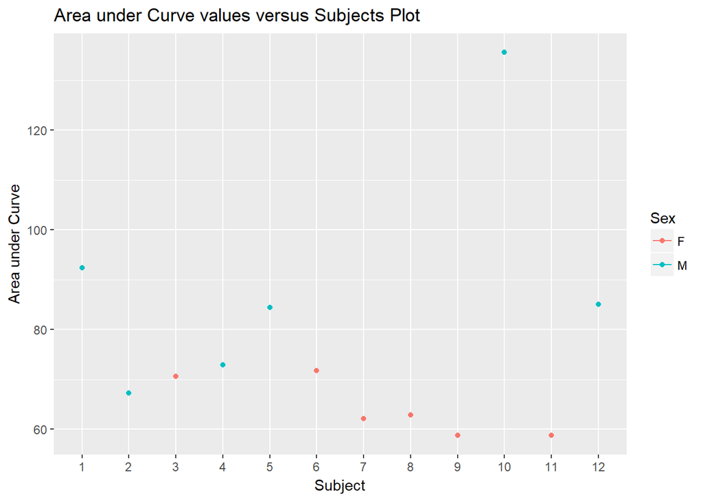

```r
A<-ggplot(data=dm, aes(x=Subject, y=AUC, color=Sex)) +
  geom_line() +
  geom_point()+ labs(x="Subject", y="Area under Curve", title= "Area under Curve values versus Subjects Plot")
A
```

```r
#p7<-ggplotly(A)
```

The above plot shows the AUC values for each subject and the red points represent the female subjects while the blue represent the male. The mean AUC values (89.57) for male is comparitively higher than the mean AUC values (64.10) for female. The significantly higher mean AUC values for male might be due to the higher AUC values for subject 10. When the AUC values for the subject 10 were omitted the mean AUC value for male is arounf 80.37, which is still significaantly higher.

```r
AUC_data<-left_join(Theoph, dm, by="Subject")
```

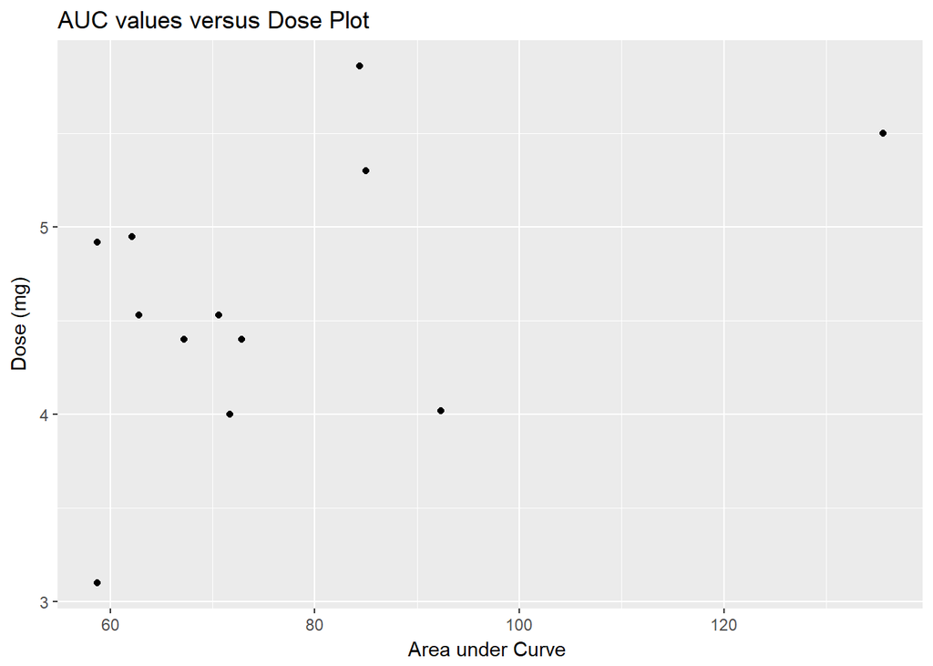

```r
plot8<-ggplot(AUC_data, aes(x=AUC, y=Dose, group= Subject)) + geom_point() +
    labs(x="Area under Curve ", y="Dose (mg)", title= "AUC values versus Dose Plot")
plot8
```

```r
#ggplotly(plot8)
```

Based on the above plot, the AUC values were higher when the dose were above 5mg except for one scenario when the dose was around 4 mg.

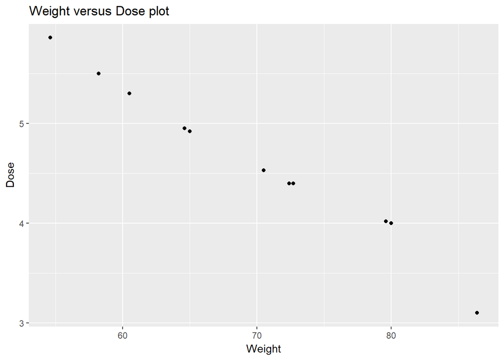

```r
plot9<-ggplot(AUC_data, aes(x=Wt, y=Dose, group=Subject))+geom_point()+labs(x="Weight", y="Dose", title= "Weight versus Dose plot")
plot9
```

```r
#ggplotly(plot9)
```

In this plot, we can clearly observe that weight and dose are inversely related and these variabilities are to be taken into consideration for each subject. A linear plot can be generated and further help in providing the information about the right dosages based on weight subjects. Overall, since the sample size is small, we cannot expand this approach for larger sample sizes.